# Lab 1: Intro to R

Karl Marx

5th May 1818

The goal of this lab is to introduce you to R and RStudio, which you’ll be using throughout the course both to learn the statistical concepts discussed in the course and to analyze real data and come to informed conclusions. The lab specifications can be found [here](https://oferengel.github.io/ims-tutorials-4-umcg/support/assignments/01_intro_to_r/).

To clarify which is which: `R` is the name of the programming language itself and RStudio is a convenient interface for working with `R` . Think of it like this:

- R is like a car’s engine,
- RStudio is like a car’s dashboard

[figure not shown]

What is the difference between R and RStudio

### Exercise 1

Knit your RMarkdown file and observe the result in the form of a knitted report. Now change the following in your RMarkdown (a) In the YAML, identify the author’s name and replace it with **your** name. (b) Replace the date to show **today’s date**. (c) Identify the sentence “The lab specifications can be found here,” and turn the word “here” into a link, (d) Add an image of the car dashboard (a metaphor for RStudio) and the car engine (a metaphor for R).

## The `arbuthnot` dataset

The Arbuthnot data set refers to the work of [Dr. John Arbuthnot](https://en.wikipedia.org/wiki/John_Arbuthnot), an 18<sup>th</sup> century physician, writer, and mathematician. He was interested in the ratio of newborn boys to newborn girls, so he gathered the baptism records for children born in London for every year from 1629 to 1710.

### Exercise 2

Load the `tidyverse` library into your environment, and then load the `arbuthnot` dataset. Now use the `glimpse` function to display its content, and the `dim` function to display its dimensions. Write down the variables associated with the dataset and the number of observations in your dataset.

```r
# Load the tidyverse library below
library(tidyverse)

# load the data into the environment
arbuthnot <- read_csv("data/arbuthnot.csv")

# Use `glimpse` function to inspect your dataset below
glimpse(arbuthnot)
```

```
## Rows: 82
## Columns: 3
## $ year  <dbl> 1629, 1630, 1631, 1632, 1633, 1634, 1635, 1636, 1637, 1638, 1639…
## $ boys  <dbl> 5218, 4858, 4422, 4994, 5158, 5035, 5106, 4917, 4703, 5359, 5366…
## $ girls <dbl> 4683, 4457, 4102, 4590, 4839, 4820, 4928, 4605, 4457, 4952, 4784…
```

```r
# Use the `dim` function to see the dimensions of your dataset
dim(arbuthnot)
```

```
## [1] 82  3
```

**Answer**: There are *3 continuous* variables in the arbuthnot dataset. The names of the variables are: `year`, `boys` and `girls`. The dataset consists of 82 observations (rows), one observation for each year.

### Exercise 3

What command would you use to extract just the counts of girls baptized? Try it out in the console!

**Answer**: To extract the counts of baptized girls, we need to use the following command: `arbuthnot$girls`

### Exercise 4

Create the plot and answer the following: is there an apparent trend in the number of girls baptized over the years? How would you describe it?

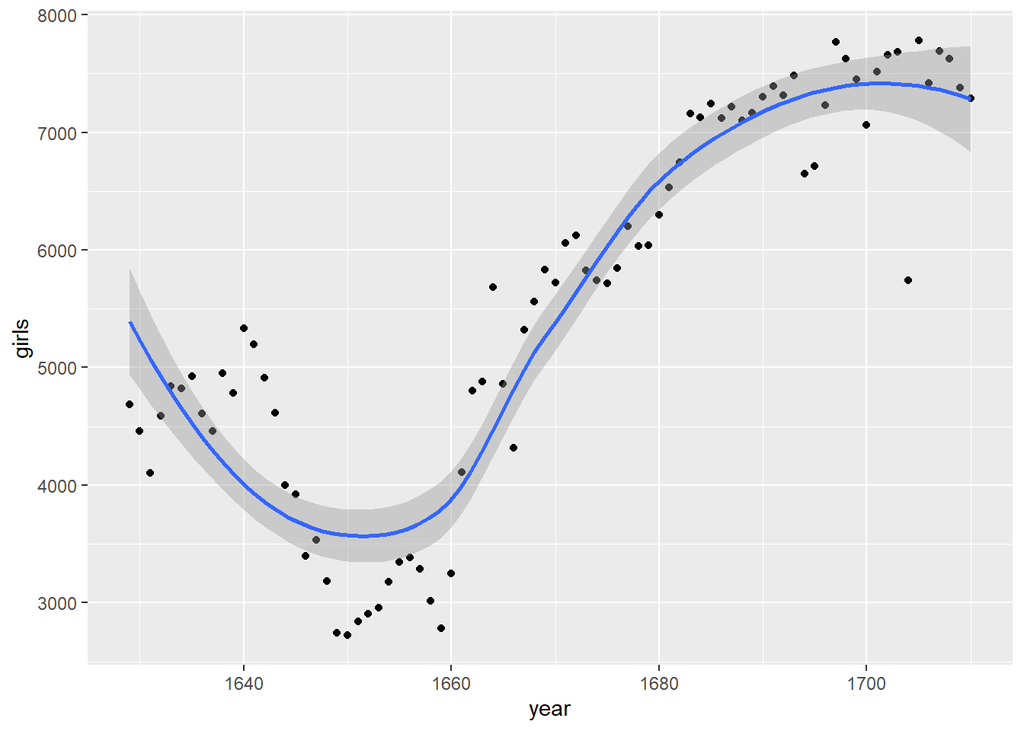

```r
# Insert code below
ggplot(
  data = arbuthnot, aes(x = year, y = girls)
  ) +
  geom_point() +
  geom_smooth()
```

**Answer**: There appears to be something of a dip in the birth of girls between the years 1640 and 1660, but the birth rate picks right up and increases steadily until the seventeen hundreds.

### Exercise 5

Now, generate a plot of the proportion of boys born over time. What do you see?

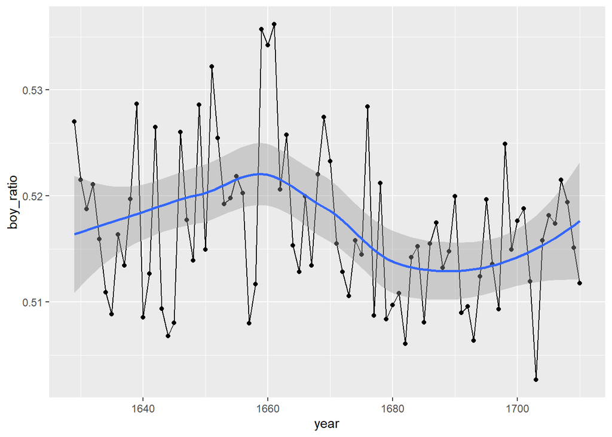

```r
# Insert code below
arbuthnot |>
  mutate(total = boys + girls ) |>
  mutate(boy_ratio = boys / total) |>
  ggplot(aes(year, boy_ratio)) +
  geom_point() +
  geom_line() +
  geom_smooth()
```

**Answer**: The proprotion varies a lot from year to year, jumping up and down but staying roughly within the interval of 0.53 and 0.51. It is hard to see a identify a clear trend in the data.

## The`present` dataset

Answer the following questions with the `present` dataset:

### Exercise 6

What years are included in this data set? What are the dimensions of the dataset? What are the variable names? How many observations are in your data?

```r
# We already loaded the tidyverse library
# so we do not need to do this again.
# However, we do need to load the new data into the environment

# Insert code below
present <- read_csv("data/present.csv")

# What years are included in the dataset?
present |>
  summarize(
    min = min(year),
    max = max(year)
    )
```

| min | max |
| --- | --- |
| 1940 | 2002 |

```r
# What are the dimensions of the dataset?
dim(present)
```

```
## [1] 63  3
```

```r
# What are the variable names?
names(present)
```

```
## [1] "year"  "boys"  "girls"
```

**Answer**: The dataset consists of data from the year 1940 to 2002. The data has three continuous variables (year, boys and girls), and 63 observations, one observation for each year.

### Exercise 7

How do these counts compare to Arbuthnot’s? Are they of a similar magnitude?

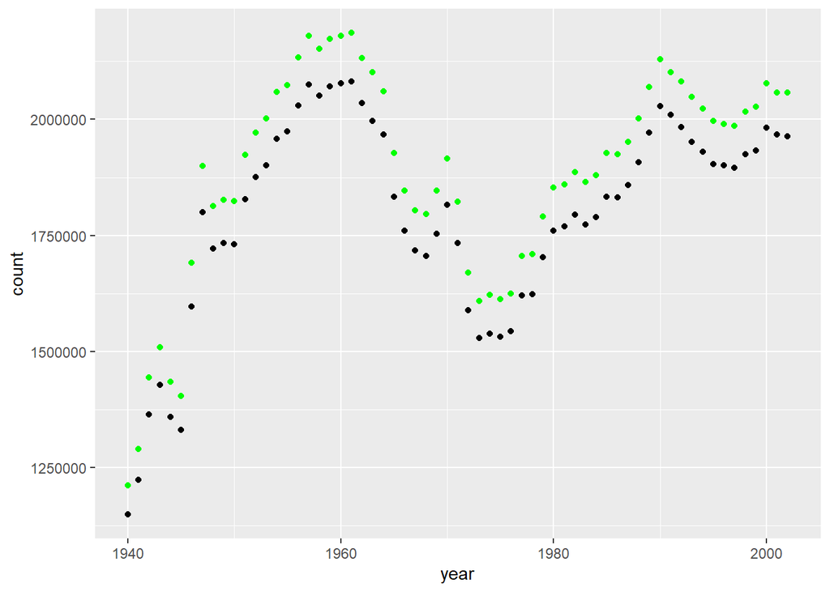

```r
# Insert code below
ggplot(
  data = present
  ) +
  geom_point(aes(x = year, y = girls), color = "black") +
  geom_point(aes(x = year, y = boys), color = "green") +
  labs(y = "count")
```

**Answer**: The numbers in the `present` dataset range between about 1 and 2 million children born per year, whereas the data in the `arbuthnot` records is in the thousands, so the `present` dataset is three degrees of magnitude larger than the `arbuthnot` dataset.

### Exercise 8

Make a plot that displays the proportion of boys born over time. What do you see? Does Arbuthnot’s observation about boys being born in greater proportion than girls hold up in the U.S.? What explains the differences you observe? Include a plot in your response.

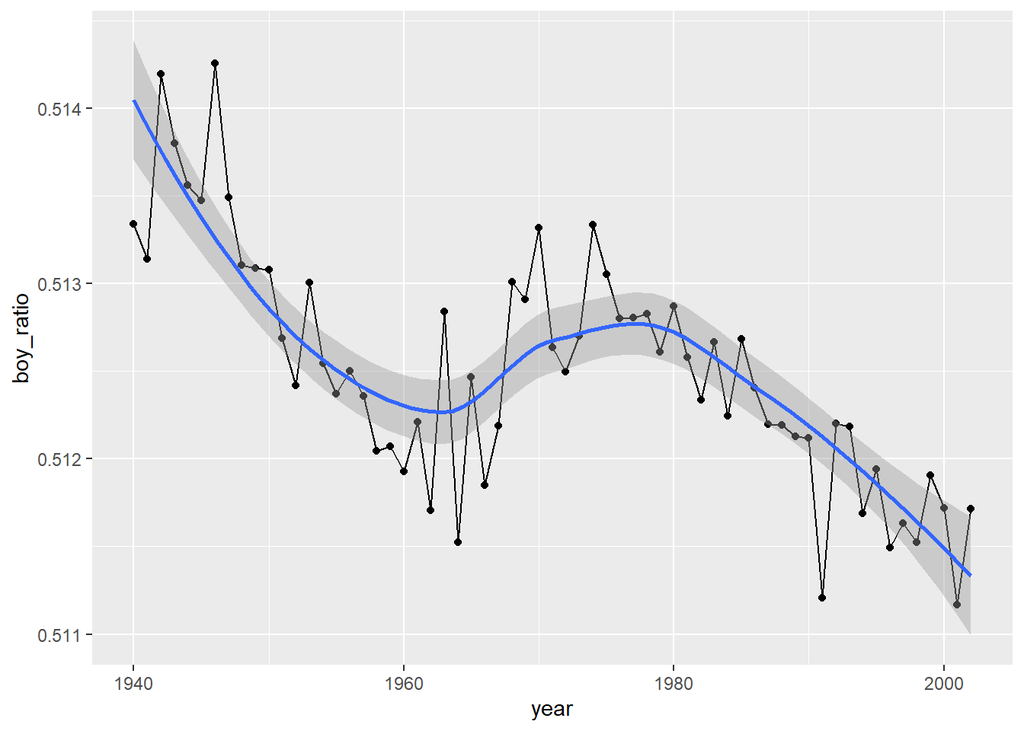

```r
# Insert code below
present |>
  mutate(total = boys + girls ) |>
  mutate(boy_ratio = boys / total) |>
  ggplot(aes(year, boy_ratio)) +
  geom_point() +
  geom_line() +
  geom_smooth()
```

**Answer**: The proportions look very similar, although the range is much smaller, varying between 0.511 and 0.514, whereas in the `arbuthnot` dataset the proportion varied between about 0.51 and 0.53. It could be that this is due to the fact that the the `present` dataset is about a much larger population, and therefore the variability in the data is much smaller.

### Exercise 9

In what year did we see the largest total number of births in the U.S.?

```r
# Insert code below
```